# Visualize the distribution of EGFR Status according to stage and age and express the primary location of EGFR Status with color

# 1.Backgorund

Reading the Proteogenomics of Non-smoking Lung Cancer in East Asia Delineates Molecular Signatures of Pathogenesis and Progression and looking at the datasheet, I wanted to know where the Primary Tumor was located and to what stage it was reached according to the status of EGFR that appears in non-smokers.

#2 Dataset First, call the required library. Then call the required data. At this time, it is said that there is no column name.

```r
library(tidyverse)
library(readxl)
library(dplyr)
library(ggplot2)

d<- read_xlsx("Table S1A_clinical_103patient.xlsx",col_names = F )
```

```
* `` -> ...1
* `` -> ...2
* `` -> ...3
* `` -> ...4
* `` -> ...5
* ...
```

#3 Visualization Use head code to see the data in the data set.

```r
head(d)
```

[output not shown]

Replace d with that of the data frame.

```r
d= d%>%
  as.data.frame()
```

Let’s check the class of d.

```r
class(d)
```

```
[1] "data.frame"
```

You called the column without a name while calling the data set, but now let’s specify the name of the column.

Let’s specify the name of column in cols. At this time, cols will be’ID’,‘Batch’,‘gender’,‘age’,‘smoking’,‘histology’,‘stage’,‘EGFR’,‘Location’.

```r
cols=c('ID','Batch','gender','age','smoking','histology','stage','EGFR','Location')
```

Call data setd again with the column name saved as cols. At this time, the first line of the data set will be skipped.

```r
d<- read_xlsx("Table S1A_clinical_103patient.xlsx",col_names = cols, skip = 1)
```

Check the class of each column of the data set using sapply

```r
sapply(d,class)
```

```
         ID       Batch      gender         age     smoking   histology       stage        EGFR
"character" "character" "character"   "numeric" "character" "character" "character" "character"
   Location
"character"
```

Create a data frame from data for Female only.

```r
m<-d%>%
  select(gender,age,smoking,stage,EGFR,Location)%>%
  filter(gender=="Female")
```

In order to finally draw the desired graph, first check the number of each EGFR type.

To get the number of EGFR by type, use the following code.

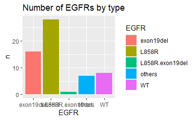

```r
m%>%
  count(EGFR)%>%
  ggplot(.,aes(EGFR,n,fill=EGFR))+geom_bar(stat = "identity",position = position_dodge())+labs(title = "Number of EGFRs by type")
```

Since the degree of cancer progression is different for each EGFR type, check the stage of each type.

To check the stage distribution by EGFR type, the following code is used.

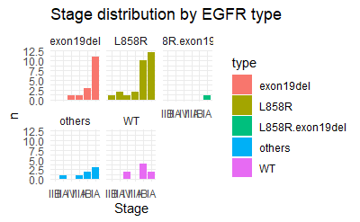

```r
bind_rows(m%>%
  filter(EGFR=="exon19del")%>%
  mutate(type= EGFR)%>%
  select(type,stage),
  m%>%
    filter(EGFR=="L858R")%>%
    mutate(type=EGFR)%>%
    select(type,stage),
  m%>%
    filter(EGFR=="L858R.exon19del")%>%
    mutate(type=EGFR)%>%
    select(type,stage),
  m%>%
     filter(EGFR=="others")%>%
  mutate(type= EGFR)%>%
  select(type,stage),
  m%>%
     filter(EGFR=="WT")%>%
  mutate(type= EGFR)%>%
  select(type,stage))%>%
  count(type,stage)%>%
  mutate(stage=factor(stage,levels = rev(unique(stage))))%>%
  ggplot(aes(stage,n,fill=type))+labs(title = 'Stage distribution by EGFR type', x='Stage',y='n')+theme_minimal()+geom_bar(stat = "identity")+facet_wrap(~type)
```

```r
NA
```

Now that we know the stage distribution for each EGFR type, let’s look at the Location distribution. To find out the location distribution by EGFR type, the following code is used.

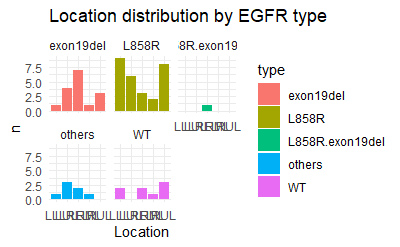

```r
bind_rows(m%>%
  filter(EGFR=="exon19del")%>%
  mutate(type= EGFR)%>%
  select(type,Location),
  m%>%
    filter(EGFR=="L858R")%>%
    mutate(type=EGFR)%>%
    select(type,Location),
  m%>%
    filter(EGFR=="L858R.exon19del")%>%
    mutate(type=EGFR)%>%
    select(type,Location),
  m%>%
     filter(EGFR=="others")%>%
  mutate(type= EGFR)%>%
  select(type,Location),
  m%>%
     filter(EGFR=="WT")%>%
  mutate(type= EGFR)%>%
  select(type,Location))%>%
  count(type,Location)%>%
  mutate(stage=factor(Location,levels = rev(unique(Location))))%>%
  ggplot(aes(Location,n,fill=type))+labs(title = 'Location distribution by EGFR type', x='Location',y='n')+theme_minimal()+geom_bar(stat = "identity")+facet_wrap(~type)
```

```r
NA
```

By examining the primary location and distribution by EGFR type of cancer according to stage and age, you can find out where the EGFR gene for each EGFR type is located and at which stage according to the stage and age.

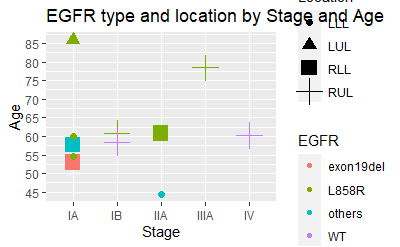

```r
m%>%
  select(age,EGFR,stage,Location)%>%
  filter(EGFR==c("exon19del","L858R","others","WT"))%>%
  ggplot(aes(stage,age))+geom_point(aes(shape=Location,color=EGFR,size=Location))+scale_y_continuous(breaks=c(40,45,50,55,60,65,70,75,80,85))+ labs(x='Stage',y = 'Age', title ="EGFR type and location by Stage and Age")
```